# Data Excerise 1: Decision Making

Vidushi Kataria

2024-10-02

This is the notebook for the Data Exercise 1, about decision making. We did a study together in class on Qualtrics, then downloaded the data to analyze.

# Loading libraries and data

```r
library(tidyverse)
```

[output not shown]

```r
library(dplyr)
```

[output not shown]

```r
de1 <- read_csv("CogSci412_DE1_Data.csv") %>%
```

[output not shown]

```r
  filter(Progress == 100 & Status == "IP Address") %>%
```

[output not shown]

```r
  mutate(condition = case_when(is.na(FL_39_DO) == FALSE ~ FL_39_DO,
```

[output not shown]

```r
                               is.na(FL_43_DO) == FALSE ~ FL_43_DO
```

[output not shown]

```r
                               )) %>%
```

[output not shown]

```r
  select(ResponseId,
```

[output not shown]

```r
         pencil_control = `Pencil Control`,
```

[output not shown]

```r
         pencil_control_conf = `Conf. Pencil Control`,
```

[output not shown]

```r
         mag_stnd = `Magazine Standard`,
```

[output not shown]

```r
         mag_stnd_conf = `Conf. Mag. Stand.`,
```

[output not shown]

```r
         mag_control = Magazine_Control,
```

[output not shown]

```r
         mag_control_conf = `Conf. Mag. Control`,
```

[output not shown]

```r
         pencil_stnd = Pencil_Standard,
```

[output not shown]

```r
         pencil_stnd_conf = `Conf. Pencil Stand.`,
```

[output not shown]

```r
         familiarity = Q10) %>%
```

[output not shown]

```r
  filter(ResponseId != "R_5R9cvvcJ5vFulLe")
```

[output not shown]

```r
de1
```

| ResponseId | pencil_control | pencil_control_conf | mag_stnd | mag_stnd_conf | mag_control | mag_control_conf | pencil_stnd | pencil_stnd_conf | familiarity |
| --- | --- | --- | --- | --- | --- | --- | --- | --- | --- |
| R_7LbZFfk5l0eIzrn | 10 | 100 | 90 | 100 | NA | NA | NA | NA | Yes |
| R_15FyEMBbNwEXgB1 | 10 | 100 | 45 | 100 | NA | NA | NA | NA | Yes |
| R_3Fs30khuUhJ9Q43 | NA | NA | NA | NA | 90 | 100 | 10 | 90 | Maybe |
| R_6j9h9CeyOAxYNCR | NA | NA | NA | NA | 0.90 | 75 | 0.05 | 75 | Yes |
| R_7fD0XwVS010KjZf | NA | NA | NA | NA | 90 | 100 | 10 | 100 | Maybe |
| R_7PuX7t6ScsmTetV | NA | NA | NA | NA | 90 | 100 | 10 | 100 | Yes |
| R_1E3RnX5eC0YwAkN | 10 | 100 | 45 cents | 100 | NA | NA | NA | NA | Yes |
| R_12Ekl4iOSy2GKcw | 10 | 100 | 90 | 100 | NA | NA | NA | NA | Maybe |
| R_1WUVktlU1pC1v2m | NA | NA | NA | NA | 90 | 100 | 10 | 100 | No |
| R_3HSIBKN4q86ZvwN | 10 cents | 90% | .90 | 90% | NA | NA | NA | NA | Yes |

[output cut: 7 more lines]

This is in WIDE form.

We want to get it into LONG form

How do we want to structure it?

Each cell (e.g., the number “10” datapoint) can be categorized with three pieces of information. What are they? - pencil vs. magazine - control vs. standard - answer vs. confidence

What we want in long form:

ResponseId: unique identifier for that dataset Content: was the question about pencils or magazines Type: was the question a control question or a standard question DV (“dependent variable”): answer, confidence

value: the actual observed number/response

How do we get the wide form de1 into this desired format?

```r
de1_long <- de1 %>%
  pivot_longer(pencil_control:pencil_stnd_conf,
               names_to = "old_column",
               values_to = "value")
```

```r
de1_long_clean <- de1_long %>%
  filter(is.na(value) == FALSE) %>%
  # check is.na() and is.na() == TRUE WHEN the thing is NA and is == FALSE when the thing is not NA
  # in this case, we're keeping all things where is.na(value) is NOT NA
  # therefore, removing the ones where is.na(value) IS NA

  separate(into = c("content", "type", "DV"),
           col = old_column) %>%

  # create new column, replacing the old one!
  # NA is replaced with "resp"
  mutate(DV = case_when(is.na(DV) == TRUE ~ "resp",
                        DV == "conf" ~ DV))
```

To interpret people’s responses:

For the pencil/eraser problem, for the standard the correct answer is 5 cents, but we’d expect lots of folks to say 10 cents. For the control problem, the correct answer is 10 cents.

For the magazine/banana problems, the correct answer for standard is 45 cents, but expect folks to say 90 cents. The correct for control is 90 cents.

## recoding values

We realized that because people could free-type, some folks included the word “cents” or wrote 0.90 instead of 90 - need to get these all in the same format

```r
de1_long_clean %>%
  filter(DV == "resp") %>%
  distinct(value)
```

| value |
| --- |
| 10 |
| 90 |
| 45 |
| 0.90 |
| 0.05 |
| 45 cents |
| 10 cents |
| .90 |
| $0.05 |
| .10 |

```r
de1_analysis <- de1_long_clean %>%
  # replace value with the number only stuff - getting rid of the words "cents" and $
  # notice that the parse_number also converted this column from a CHR vector to a DBL vector
  # so now it's storing it as a NUMBER than TEXT
  mutate(value = parse_number(value)) %>%
  # we still have some issues with 0.90 and 0.05, these only happen when < 1 though
  mutate(value = case_when(value < 1 ~ value*100, # when it's a decimal number, multiply * 100
                           value >= 1 ~ value)) %>%  # when it's above one, keep it as is

  mutate(correct_answer = case_when(content == "pencil" & type == "stnd" ~ 5,
                                    content == "pencil" & type == "control" ~ 10,
                                    content == "mag" & type == "stnd" ~ 45,
                                    content == "mag" & type == "control" ~ 90),

         # create a new column for that person's accuracy on that trial
         # to see how if_else works, when you have one condition and then EVERYTHING ELSE
         accuracy = case_when(DV == "conf" ~ NA,
                              value == correct_answer ~ TRUE,
                              value != correct_answer ~ FALSE)
  )
```

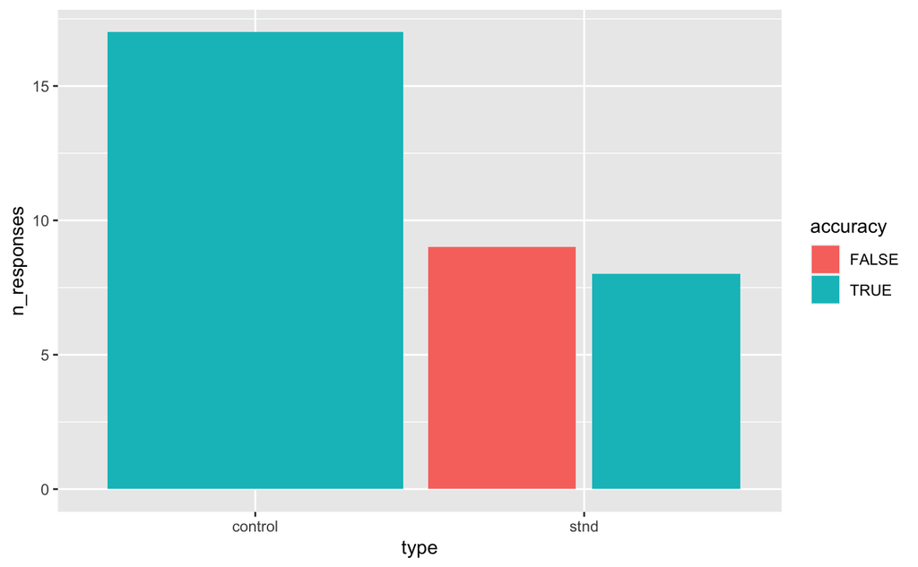

```r
de1_analysis %>%
  filter(DV == "resp") %>%
  group_by(type, accuracy) %>%
  summarise(n_responses = n()) %>%

  ggplot(aes(x = type, y = n_responses, fill = accuracy)) +
  geom_bar(stat = "identity",
           position = position_dodge(1))
```

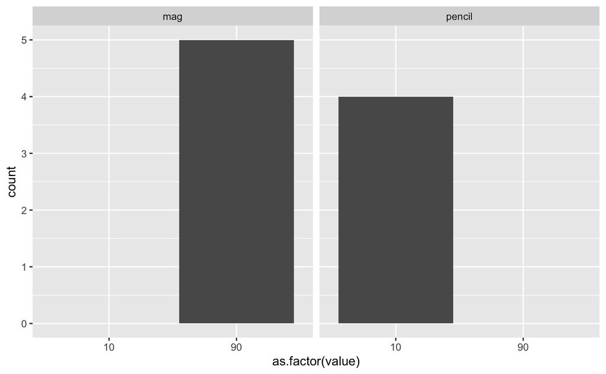

```r
de1_analysis %>%
  filter(DV == "resp"
         & type == "stnd"
         & accuracy == FALSE) %>%
  ggplot(aes(x = as.factor(value))) +
  geom_bar() +
  facet_grid(~content)
```